# How can I make my League of Legends team work more effectively?

Cole Watkins

# Introduction

League of Legends is one of the first MOBA-style games, and it is from the developer Riot Games. Two teams of five "champions" must compete against each other to destroy each other's structures and compete over objectives to ultimately destroy the other team's main base called the nexus. Each team consists of a player in the top lane, a player in the middle lane, a player in between the lanes in an area called the "jungle", and two players in the bottom lane. There are a litany of game mechanics to learn and master, and I will be comparing myself and my friend's proficiencies in some of these game mechanics.

I have a thought in my head of who is better or worse at this game in my friend group, but I would like to get into the nitty gritty of who's the best/worst at specific game mechanics, or who's the best in each lane in order for us to work better together as a team, or even just something to help me get better at the game, as I adore improving at my video game skill.

```python
import pandas as pd
import numpy as np
import requests
from bs4 import BeautifulSoup
import matplotlib.pyplot as plt
from matplotlib.pyplot import figure
import time
```

# Data Wrangling

I will be using Riot's own API. This API requires that you first request by summoner name (which is the in-game username) and then request by that summoner's accountid, which is a value hidden to a typical user.

```python
apikey = "RGAPI-429d0d4c-cb7f-4b0a-b668-d58d29e15213"
riot = requests.get("https://na1.api.riotgames.com/lol/summoner/v4/summoners/by-name/Coolgum15?api_key={}".format(apikey))
riot
#Response 200 = correct request
```

```
<Response [200]>
```

This second request will vary on what queue type you are looking for. My friends and I play mostly normal games and ARAM games, which are just two different queue types, so I will be looking at queue=400 (normals). ARAM game data is not tracked very well, so we will not be examining it.

Queue ids can be found here: https://static.developer.riotgames.com/docs/lol/queues.json

The other value you have to pay attention to is season. I personally have played a lot this current season, which is season 11, so I will be using season=13. Season ID for the previous few seasons is under this ID.

Additionally, since season ID is deprecated, you'll have to manually check the dataframe pulled from the API request to make sure it has this year's games. This can be done by cross-referencing the dataframe with League of Legends' match history (https://matchhistory.na.leagueoflegends.com/en/#match-history) and by checking the number of games you have in your League of Legends client. (Profile -> stats -> hover over games played to see queue type). Sadly this does not count ARAM games, so that would also have to be manually checked.

Data requests can only have 100 matches per request, so we'll have to make multiple requests and stitch them together. Furthermore, the API limits requests to 20 requests per second or 100 requests per 2 minutes, so this implementation must be built around that.

Once we have retrieved these values, we must isolate the matches data from the request into a dataframe.

```python
#returns a dataframe from account #summoner, in queue type #queue, with #num number of matches using #api api key
def get_matches(summoner, api, queue, num):
    riot = requests.get("https://na1.api.riotgames.com/lol/summoner/v4/summoners/by-name/{}?api_key={}".format(summoner, apikey))
    riot_json = riot.json()
    acc_id = riot_json['accountId']
    req = requests.get("https://na1.api.riotgames.com/lol/match/v4/matchlists/by-account/{}?queue={}&season=13&api_key={}".format(acc_id, queue, apikey))
    req_json = req.json()
    matches = req_json['matches']
    df = pd.DataFrame.from_dict(matches)
    for count in range(100, num, 100):
        if (count + 100) < num:
            end = count + 100
        else:
            end = num
        req = requests.get("https://na1.api.riotgames.com/lol/match/v4/matchlists/by-account/{}?queue={}&season=13&endIndex={}&beginIndex={}&api_key={}".format(acc_id, queue, end, count, apikey))
        matches = req.json()['matches']
        df2 = pd.DataFrame.from_dict(matches)
        df = pd.concat([df, df2])
    return df
```

I have had 187 normal games of League of Legends this year, and I will compare this data to the same data my friends have achieved in the past 187 normal games.

```python
#Users to be compared as I will be using first names in code for my sake.
#Coolgum15 = Cole
#Rotome = Jerry
#Dublaiar = Aidan
#requests via function

cole_norms = get_matches("Coolgum15", apikey, 400, 187)
aidan_norms = get_matches("Dublaiar", apikey, 400, 187)
jerry_norms = get_matches("Rotome", apikey, 400, 187)
cole_norms.head()
```

|  | platformId | gameId | champion | queue | season | timestamp | role | lane |
| --- | --- | --- | --- | --- | --- | --- | --- | --- |
| 0 | NA1 | 3983143443 | 7 | 400 | 13 | 1626782669904 | SOLO | MID |
| 1 | NA1 | 3983058963 | 83 | 400 | 13 | 1626775632895 | SOLO | TOP |
| 2 | NA1 | 3983086561 | 143 | 400 | 13 | 1626773645888 | DUO_SUPPORT | BOTTOM |
| 3 | NA1 | 3981851859 | 268 | 400 | 13 | 1626662105480 | DUO | TOP |
| 4 | NA1 | 3980383193 | 268 | 400 | 13 | 1626562870130 | DUO_SUPPORT | NONE |

Then we can request once again, this time using the gameId from the above dataframe to get the specific data of that match. Since this will be processing a large number of requests, as we must make a request for each match (187 per player!), the requests must be structured around the previously mentioned 100 requests per 2 minutes.

From this request, we are going to isolate teammate data for analysis.

From this isolated teammate data, we will also remove unnecessary columns that represent parts of the game that do not impact performance (such as summoner icon), counters that don't tell us much (like number of ability casts, which varies greatly across champions), deprecated game features (like purchasable vision wards that are not control wards), account details (like IDs), or champion specific mechanics (like transformations).

Additionally, some matches when requested are simply just missing parameters. For example, some columns just may not exist in a match dataframe. I have no idea why this happens, but it's out of your control and sometimes a group of matches just won't pull to your formatting if you're pulling data based on a missing column.

```python
def match_data(api, df):
    #create new dataframe
    game_id = df['gameId'].tolist()
    data = []
    for i in game_id:
        #100 requests / 120 seconds ~= .9 sleep between requests.
        time.sleep(.9)
        #append to existing dataframe
        req = requests.get("https://americas.api.riotgames.com/lol/match/v5/matches/NA1_{}?api_key={}".format(i, api))
        req_json = req.json()
        df2 = pd.DataFrame.from_dict(req_json['info']['participants'])
        df2 = df2.drop(columns=['championTransform', 'damageSelfMitigated', 'goldSpent', 'itemsPurchased', 'lane',
                                'largestCriticalStrike', 'nexusKills', 'pentaKills',
                                'perks', 'profileIcon', 'quadraKills', 'riotIdName', 'riotIdTagline',
                                'sightWardsBoughtInGame', 'spell1Casts', 'spell2Casts', 'spell3Casts', 'spell4Casts',
                                'puuid', 'summonerId', 'totalDamageShieldedOnTeammates', 'totalHealsOnTeammates',
                                'tripleKills', 'unrealKills', 'champExperience', 'consumablesPurchased',
                                'doubleKills', 'championId'])
        data.append(df2)
    return data
```

```python
#these are all separate, as each takes 4 minutes to request all matches
pd.set_option('display.max_columns', 15)
cole_matches = match_data(apikey, cole_norms)
cole_matches[0]
```

|  | assists | baronKills | bountyLevel | champLevel | championName | damageDealtToBuildings | damageDealtToObjectives | ... | turretTakedowns | turretsLost | visionScore | visionWardsBoughtInGame | wardsKilled | wardsPlaced | win |
| --- | --- | --- | --- | --- | --- | --- | --- | --- | --- | --- | --- | --- | --- | --- | --- |
| 0 | 13 | 0 | 3 | 16 | Aatrox | 6199 | 17239 | ... | 3 | 0 | 18 | 0 | 0 | 10 | True |
| 1 | 5 | 0 | 1 | 16 | Shaco | 900 | 19684 | ... | 0 | 0 | 11 | 0 | 3 | 0 | True |
| 2 | 7 | 0 | 3 | 16 | Azir | 11087 | 21018 | ... | 5 | 0 | 11 | 0 | 0 | 6 | True |
| 3 | 13 | 0 | 0 | 16 | Twitch | 2055 | 8631 | ... | 3 | 0 | 11 | 0 | 0 | 10 | True |
| 4 | 22 | 0 | 0 | 14 | Seraphine | 1998 | 5845 | ... | 3 | 0 | 77 | 4 | 10 | 33 | True |
| 5 | 6 | 0 | 0 | 15 | DrMundo | 1030 | 1030 | ... | 0 | 9 | 8 | 0 | 1 | 4 | False |
| 6 | 5 | 1 | 0 | 15 | Kindred | 536 | 3598 | ... | 1 | 9 | 22 | 0 | 2 | 11 | False |
| 7 | 9 | 0 | 0 | 15 | Draven | 0 | 339 | ... | 0 | 9 | 12 | 0 | 1 | 8 | False |
| 8 | 7 | 0 | 1 | 16 | Jhin | 0 | 0 | ... | 0 | 9 | 14 | 3 | 2 | 11 | False |
| 9 | 12 | 0 | 0 | 14 | Xerath | 0 | 234 | ... | 0 | 9 | 60 | 5 | 8 | 22 | False |

10 rows × 77 columns

```python
jerry_matches = match_data(apikey, jerry_norms)
jerry_matches[0]
```

|  | assists | baronKills | bountyLevel | champLevel | championName | damageDealtToBuildings | damageDealtToObjectives | ... | turretTakedowns | turretsLost | visionScore | visionWardsBoughtInGame | wardsKilled | wardsPlaced | win |
| --- | --- | --- | --- | --- | --- | --- | --- | --- | --- | --- | --- | --- | --- | --- | --- |
| 0 | 10 | 0 | 7 | 16 | Sion | 5455 | 5938 | ... | 2 | 1 | 13 | 3 | 0 | 10 | True |
| 1 | 24 | 0 | 0 | 14 | Rammus | 719 | 22468 | ... | 3 | 1 | 27 | 3 | 2 | 11 | True |
| 2 | 11 | 1 | 0 | 15 | Gwen | 3519 | 10038 | ... | 3 | 1 | 16 | 0 | 1 | 9 | True |
| 3 | 12 | 0 | 2 | 15 | Jinx | 15109 | 27417 | ... | 7 | 1 | 6 | 0 | 0 | 4 | True |
| 4 | 22 | 0 | 0 | 14 | Morgana | 2655 | 15695 | ... | 6 | 1 | 48 | 3 | 1 | 17 | True |
| 5 | 5 | 0 | 0 | 16 | Udyr | 3566 | 8563 | ... | 1 | 11 | 13 | 0 | 1 | 9 | False |
| 6 | 9 | 0 | 0 | 13 | Trundle | 565 | 5785 | ... | 1 | 11 | 25 | 2 | 2 | 6 | False |
| 7 | 5 | 0 | 0 | 14 | TwistedFate | 185 | 1269 | ... | 0 | 11 | 11 | 0 | 0 | 7 | False |
| 8 | 8 | 0 | 0 | 13 | Kaisa | 1757 | 2295 | ... | 0 | 11 | 9 | 0 | 1 | 5 | False |
| 9 | 9 | 0 | 0 | 12 | Nautilus | 0 | 582 | ... | 0 | 11 | 26 | 2 | 3 | 12 | False |

10 rows × 77 columns

```python
aidan_matches = match_data(apikey, aidan_norms)
aidan_matches[0]
```

|  | assists | baronKills | bountyLevel | champLevel | championName | damageDealtToBuildings | damageDealtToObjectives | ... | turretTakedowns | turretsLost | visionScore | visionWardsBoughtInGame | wardsKilled | wardsPlaced | win |
| --- | --- | --- | --- | --- | --- | --- | --- | --- | --- | --- | --- | --- | --- | --- | --- |
| 0 | 6 | 0 | 1 | 12 | Gangplank | 1405 | 1405 | ... | 2 | 2 | 11 | 2 | 1 | 7 | True |
| 1 | 11 | 0 | 0 | 13 | RekSai | 946 | 25474 | ... | 1 | 2 | 13 | 4 | 0 | 4 | True |
| 2 | 4 | 0 | 0 | 13 | Zed | 2718 | 4381 | ... | 4 | 2 | 12 | 0 | 2 | 5 | True |
| 3 | 15 | 0 | 0 | 12 | Caitlyn | 10058 | 11572 | ... | 9 | 2 | 16 | 1 | 0 | 7 | True |
| 4 | 9 | 0 | 14 | 13 | Lux | 9394 | 11852 | ... | 8 | 2 | 36 | 0 | 1 | 23 | True |
| 5 | 2 | 0 | 2 | 14 | Darius | 3699 | 4031 | ... | 1 | 11 | 13 | 0 | 1 | 7 | False |
| 6 | 5 | 0 | 0 | 11 | Kayn | 440 | 10964 | ... | 1 | 11 | 8 | 1 | 1 | 1 | False |
| 7 | 3 | 0 | 0 | 12 | Qiyana | 1767 | 4173 | ... | 1 | 11 | 15 | 2 | 0 | 8 | False |
| 8 | 1 | 0 | 0 | 11 | Jhin | 0 | 1334 | ... | 0 | 11 | 6 | 1 | 0 | 5 | False |
| 9 | 8 | 0 | 0 | 12 | Nami | 366 | 891 | ... | 1 | 11 | 20 | 0 | 1 | 9 | False |

10 rows × 77 columns

# Win rates

There are a lot of game aspects in League of Legends to examine, so let's look at the result of all the mechanics: win rate. This will be done by finding each user's summonerName in the column in the dataframe and the win column. Each role (Top, jungle, middle, bottom, and support, AKA: top, jg, mid, bot, supp) will be examined.

Now each player plays certain roles more/less frequently. We can also track role frequency to better assess the player's skill.

We will remove any role under 5% play rate, which is about 10 games. Anything less than 10 games tells us very little about their performance in a lane.

I'm anticipating Rotome will have the highest win rate, and Dublaiar will have to lowest.

```python
cole_matches[0]
```

|  | assists | baronKills | bountyLevel | champLevel | championName | damageDealtToBuildings | damageDealtToObjectives | ... | turretTakedowns | turretsLost | visionScore | visionWardsBoughtInGame | wardsKilled | wardsPlaced | win |
| --- | --- | --- | --- | --- | --- | --- | --- | --- | --- | --- | --- | --- | --- | --- | --- |
| 0 | 13 | 0 | 3 | 16 | Aatrox | 6199 | 17239 | ... | 3 | 0 | 18 | 0 | 0 | 10 | True |
| 1 | 5 | 0 | 1 | 16 | Shaco | 900 | 19684 | ... | 0 | 0 | 11 | 0 | 3 | 0 | True |
| 2 | 7 | 0 | 3 | 16 | Azir | 11087 | 21018 | ... | 5 | 0 | 11 | 0 | 0 | 6 | True |
| 3 | 13 | 0 | 0 | 16 | Twitch | 2055 | 8631 | ... | 3 | 0 | 11 | 0 | 0 | 10 | True |
| 4 | 22 | 0 | 0 | 14 | Seraphine | 1998 | 5845 | ... | 3 | 0 | 77 | 4 | 10 | 33 | True |
| 5 | 6 | 0 | 0 | 15 | DrMundo | 1030 | 1030 | ... | 0 | 9 | 8 | 0 | 1 | 4 | False |
| 6 | 5 | 1 | 0 | 15 | Kindred | 536 | 3598 | ... | 1 | 9 | 22 | 0 | 2 | 11 | False |
| 7 | 9 | 0 | 0 | 15 | Draven | 0 | 339 | ... | 0 | 9 | 12 | 0 | 1 | 8 | False |
| 8 | 7 | 0 | 1 | 16 | Jhin | 0 | 0 | ... | 0 | 9 | 14 | 3 | 2 | 11 | False |
| 9 | 12 | 0 | 0 | 14 | Xerath | 0 | 234 | ... | 0 | 9 | 60 | 5 | 8 | 22 | False |

10 rows × 77 columns

```python
#categorial to numeric conversion for @lane s
def numeric_lane(lane):
    if lane == 'TOP':
        return 0
    elif lane == 'JUNGLE':
        return 1
    elif lane == 'MIDDLE':
        return 2
    elif lane == 'BOTTOM':
        return 3
    else:
        return 4
```

```python
#finds winrates for a @summoner in a list of dataframes @match_list
def winrates(summoner, match_list):
    #tuple with role, num wins, and num games for winrates
    #indexes bottom up are top, jg, mid, bot, supp (AKA utility)
    match = [('TOP', 0, 0), ('JUNGLE', 0, 0), ('MIDDLE', 0, 0),
             ('BOTTOM', 0, 0), ('UTILITY', 0, 0)]
    for i in match_list:
        lane = i.loc[i['summonerName'] == summoner]['teamPosition'].tolist()[0]
        lane = numeric_lane(lane)
        win = i.loc[i['summonerName'] == summoner]['win'].bool()
        #since tuples are immutable we have to create another
        lane_data = list(match[lane])
        if win:
            lane_data[1] += 1
            lane_data[2] += 1
        else:
            lane_data[2] += 1
        match[lane] = tuple(lane_data)
    #create df and columns with data
    df = pd.DataFrame(match, columns =['Role', 'numWins', 'numGames'])
    df['winrate%'] = df['numWins']/df['numGames']*100
    df['playrate%'] = df['numGames']/187*100
    df['summonerName'] = summoner
    df['averageWinrate%'] = df['numWins'].sum()/187*100
    return df
```

```python
#removes rows from a dataframe @df if the playrate of that lane is under 5%
def remove_low(df):
    drop = []
    for index, row in df.iterrows():
        if row['playrate%'] < 5:
            drop.append(index)
    df = df.drop(drop)
    return df
```

```python
#get winrate data with winrates() and remove playrates under 5% with remove_low()
cole_winrates = winrates('Coolgum15', cole_matches)
cole_winrates = remove_low(cole_winrates)
jerry_winrates = winrates('Rotome', jerry_matches)
jerry_winrates = remove_low(jerry_winrates)
aidan_winrates = winrates('Dublaiar', aidan_matches)
aidan_winrates = remove_low(aidan_winrates)
wins = pd.concat([cole_winrates, jerry_winrates, aidan_winrates])
wins = wins.reset_index(drop = True)
wins
```

|  | Role | numWins | numGames | winrate% | playrate% | summonerName | averageWinrate% |
| --- | --- | --- | --- | --- | --- | --- | --- |
| 0 | TOP | 20 | 37 | 54.054054 | 19.786096 | Coolgum15 | 50.267380 |
| 1 | JUNGLE | 26 | 56 | 46.428571 | 29.946524 | Coolgum15 | 50.267380 |
| 2 | MIDDLE | 23 | 48 | 47.916667 | 25.668449 | Coolgum15 | 50.267380 |
| 3 | BOTTOM | 11 | 22 | 50.000000 | 11.764706 | Coolgum15 | 50.267380 |
| 4 | UTILITY | 14 | 24 | 58.333333 | 12.834225 | Coolgum15 | 50.267380 |
| 5 | TOP | 9 | 18 | 50.000000 | 9.625668 | Rotome | 54.545455 |
| 6 | JUNGLE | 6 | 14 | 42.857143 | 7.486631 | Rotome | 54.545455 |
| 7 | MIDDLE | 79 | 143 | 55.244755 | 76.470588 | Rotome | 54.545455 |
| 8 | MIDDLE | 5 | 11 | 45.454545 | 5.882353 | Dublaiar | 47.058824 |
| 9 | BOTTOM | 70 | 148 | 47.297297 | 79.144385 | Dublaiar | 47.058824 |
| 10 | UTILITY | 11 | 21 | 52.380952 | 11.229947 | Dublaiar | 47.058824 |

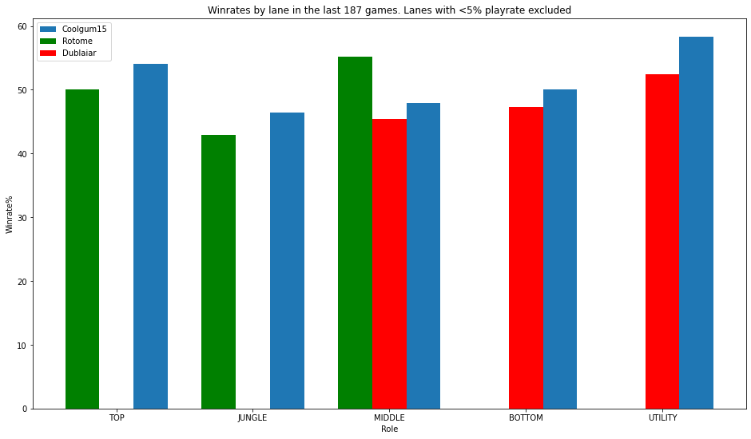

```python
players = ['Coolgum15', 'Rotome', 'Dublaiar']
roles = cole_winrates['Role'].tolist()
values = cole_winrates['winrate%'].tolist()
#graph labels
x = np.arange(len(roles))
width = .25
fig, ax = plt.subplots()
ax.set_ylabel('Winrate%')
ax.set_xlabel('Role')
ax.set_title('Winrates by lane in the last 187 games. Lanes with <5% playrate excluded')
ax.set_xticks(x)
ax.set_xticklabels(roles)
#graph data
ax.bar(x + width, values, width, label = 'Coolgum15')
jerry_w = jerry_winrates['winrate%'].tolist()
jerry_w.extend([0,0])
ax.bar(x - width, jerry_w, width, color='green', label="Rotome")
aidan_w = [0,0]
aidan_w.extend(aidan_winrates['winrate%'].tolist())
ax.bar(x, aidan_w, width, color='red', label="Dublaiar")
ax.legend(players)
fig.set_size_inches(16, 9)
```

The data confirms my suspicions! There is also some interesting data here for Coolgum15 and Dublaiar. In their most played roles (Coolgum15: Jungle, Middle and Dublaiar: Bottom), the win rate is below 50%. This data shows that those two players should play other roles with higher win rates if they wish to contribute more to the team overall.

# Skewed Matchmaking

There is a complaint in our friend group that I would like to investigate. One person, David, that we play with sometimes, is better than us at League of Legends. When he plays with us, League of Legends acknowledges his skill level, and pick harder opponents for us. To keep us from playing above our skill level, he goes on a new account called a "smurf" where League of Legends shouldn't have detected his skill level. So let's look into games where we play with his account or his smurf: StalwartHide / RyeBreadPitt

I will also be removing entries for lanes with no data, as there are lanes with no data due to not playing a lot of games of League with David.

Since we are looking at performance with David overall, we can remove lane-specific columns to get a cleaner representation.

```python
#finds winrates for a @summoner in a list of dataframes @match_list while present with the player @david
def winrates_with_david(summoner, match_list, david):
    #tuple with role, num wins, and num games for winrates
    #indexes bottom up are top, jg, mid, bot, supp (AKA utility)
    match = [('TOP', 0, 0), ('JUNGLE', 0, 0), ('MIDDLE', 0, 0),
             ('BOTTOM', 0, 0), ('UTILITY', 0, 0)]
    count = 0
    for i in match_list:
        if david in i['summonerName'].tolist():
            lane = i.loc[i['summonerName'] == summoner]['teamPosition'].tolist()[0]
            lane = numeric_lane(lane)
            win = i.loc[i['summonerName'] == summoner]['win'].bool()
            #since tuples are immutable we have to create another
            lane_data = list(match[lane])
            if win:
                lane_data[1] += 1
                lane_data[2] += 1
            else:
                lane_data[2] += 1
            match[lane] = tuple(lane_data)
            count += 1
    df = pd.DataFrame(match, columns =['Role', 'numWins', 'numGames'])
    df['winrate%'] = df['numWins']/df['numGames']*100
    df['playrate%'] = df['numGames']/count*100
    df['summonerName'] = summoner
    df['averageWinrate_with_David%'] = df['numWins'].sum()/count*100
    df['davidAccount'] = david
    return df
```

```python
#get winrates for each player with they are with each david account and add their original winrate
cole_stalwart = winrates_with_david('Coolgum15', cole_matches, 'StalwartHide')
cole_stalwart['original_winrate%'] = cole_winrates['averageWinrate%']
cole_rye = winrates_with_david('Coolgum15', cole_matches, 'RyeBreadPitt')
cole_rye['original_winrate%'] = cole_winrates['averageWinrate%']
jerry_stalwart = winrates_with_david('Rotome', jerry_matches, 'StalwartHide')
jerry_stalwart['original_winrate%'] = jerry_winrates['averageWinrate%']
jerry_rye = winrates_with_david('Rotome', jerry_matches, 'RyeBreadPitt')
jerry_rye['original_winrate%'] = jerry_winrates['averageWinrate%']
aidan_stalwart = winrates_with_david('Dublaiar', aidan_matches, 'StalwartHide')
aidan_stalwart['original_winrate%'] = aidan_winrates['averageWinrate%']
aidan_rye = winrates_with_david('Dublaiar', aidan_matches, 'RyeBreadPitt')
aidan_rye['original_winrate%'] = aidan_winrates['averageWinrate%']

#combine dataframes and remove irrelevant columns
wins = pd.concat([cole_stalwart, cole_rye, jerry_stalwart, jerry_rye, aidan_stalwart, aidan_rye])
wins = wins.dropna()
wins = wins.reset_index(drop = True)
wins = wins.drop(['winrate%', 'playrate%', 'Role'],axis=1)
wins = wins.groupby(['summonerName','davidAccount','averageWinrate_with_David%','original_winrate%']).sum()
wins
```

| summonerName | davidAccount | averageWinrate_with_David% | original_winrate% | numWins | numGames |
| --- | --- | --- | --- | --- | --- |
| Coolgum15 | RyeBreadPitt | 61.111111 | 50.267380 | 11 | 18 |
|  | StalwartHide | 43.750000 | 50.267380 | 7 | 16 |
| Dublaiar | RyeBreadPitt | 47.826087 | 47.058824 | 11 | 23 |
|  | StalwartHide | 58.333333 | 47.058824 | 14 | 24 |
| Rotome | RyeBreadPitt | 45.833333 | 54.545455 | 9 | 22 |
|  | StalwartHide | 53.846154 | 54.545455 | 25 | 47 |

The data here is quite mixed. Some players perform better when David is on StalwartHide (Dublaiar) and others perform worse. Some players perform better when David is on RyeBreadPitt (Coolgum15) and others perform worse. I would say that the smurf has no overall impact if we all played a game together, but if a single player were to play a game with only David, they could be very excited or not interested at all depending on the account. However, I can definitely confirm my suspicions that playing with David's main account StalwartHide is harder than a game without him for me (Coolgum15).

Now let's look into the parts of gameplay that are not great in order to improve a player's gameplay and their win rates.

# Creep Score (CS)

In League of Legends, one of the most important aspects of your gameplay is how much money you earn. A large amount of money can come from kills, but an even larger amount can be gained through killing enemy minions or neutral jungle monsters. Killing enemy minions and jungle monsters will contribute to your creep score, or CS. I want to investigate how creep score impacts each player's win rate. Specifically, I want to examine how creep score difference from a player's lane opponent impacts their win rate.

I'm choosing to represent all players on one graph in order to make comparisons easier, despite the messy nature of combining graphs.

In this representation, we will find the lane opponent in each match and find the difference between the player and the opponent. Then, CS difference, along with whether that match was a win/loss, will be split into several different buckets that are in a range of <(-50) to >50 cs difference in increments of 10. The overall win rate of each bucket will be plotted. The reason this was done is because the data is too small to do winrate by singular CS differences, and would give a plot that would have tons of missing data and would be next to meaningless.

```python
#calculates the winrates of range <-50 to >50 cs differences in increments of 10 from a @summoner s @matches
def cs_diff(summoner, matches):
    #list of tuples in the form of (int cs difference, bool win)
    diff = []
    #find cs diff and win/loss
    for i in matches:
        #no support games
        if i.loc[i['summonerName'] == summoner]['teamPosition'].tolist()[0] != 'UTILITY':
            #find enemy
            lane = i.loc[i['summonerName'] == summoner]['teamPosition'].tolist()[0]
            enemy = i.loc[i['teamPosition'] == lane]
            enemy = enemy.loc[enemy['summonerName'] != summoner]['summonerName'].tolist()
            #rare case where there was no lane opponent. Missing data handling
            if enemy != []:
                enemy = enemy[0]
                #find cs difference
                summ_jg = i.loc[i['summonerName'] == summoner]['totalMinionsKilled'].tolist()[0]
                summ_min = i.loc[i['summonerName'] == summoner]['neutralMinionsKilled'].tolist()[0]
                summcs =  summ_jg + summ_min
                enemy_jg = i.loc[i['summonerName'] == enemy]['totalMinionsKilled'].tolist()[0]
                enemy_min = i.loc[i['summonerName'] == summoner]['neutralMinionsKilled'].tolist()[0]
                enemycs = enemy_jg + enemy_min
                csdiff = summcs - enemycs

                win = i.loc[i['summonerName'] == summoner]['win'].bool()
                diff.append((csdiff, win))
    #cs differce buckets incrementing by 10 from <-50 to >50
    cs = []
    #<-50
    bucket = []
    for (a,b) in diff:
        if a <=-50:
            if b:
                bucket.append(1)
            else:
                bucket.append(0)
    cs.append(bucket)
    #increments
    bucket = []
    count = 1
    for i in range(-40, 51, 10):
        bucket = []
        for (a,b) in diff:
            if a <= i and a > i-10:
                if b:
                    bucket.append(1)
                else:
                    bucket.append(0)
        cs.append(bucket)
        count += 1
    #>50
    bucket = []
    for (a,b) in diff:
        if a >50:
            if b:
                bucket.append(1)
            else:
                bucket.append(0)
    cs.append(bucket)
    #calculate winrates for each cs bucket
    cs_winrate = []
    size = []
    for i in cs:
        win = 0
        win = sum(i)
        #rare case of no cs diff in that bucket.
        #to treat this missing case we just use a middling 50 percent winrate (ie no impact)
        if len(i) != 0:
            cs_winrate.append(win/len(i)*100)
        else:
            cs_winrate.append(50)
        size.append(len(i))
    return cs_winrate, size
```

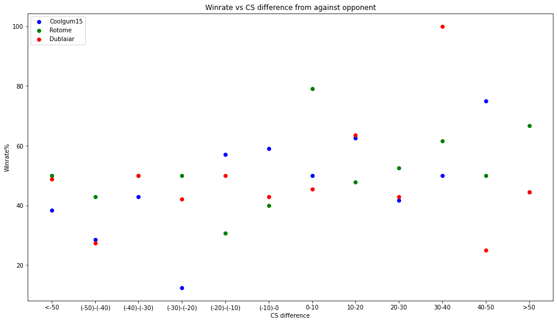

```python
#gather data via function
players = ['Coolgum15', 'Rotome', 'Dublaiar']
cole_cs, cole_size = cs_diff('Coolgum15', cole_matches)
jerry_cs, jerry_size = cs_diff('Rotome', jerry_matches)
aidan_cs, aidan_size = cs_diff('Dublaiar', aidan_matches)
#graph data
buckets = ['<-50', '(-50)-(-40)', '(-40)-(-30)', '(-30)-(-20)', '(-20)-(-10)',
           '(-10)-0', '0-10', '10-20', '20-30', '30-40', '40-50', '>50']
fig, ax = plt.subplots()
ax.set_ylabel('Winrate%')
ax.set_xlabel('CS difference')
ax.set_title('Winrate vs CS difference from against opponent')
fig.set_size_inches(16,9)
#plot each player
ax.scatter(buckets, cole_cs, color = 'blue')
ax.scatter(buckets, jerry_cs, color = 'green')
ax.scatter(buckets, aidan_cs, color = 'red')
ax.legend(players, loc = 'upper left')
```

This data is hard to interpret, so we'll implement a linear regression line for each player's data. The main reason we are using a linear regression is that CS difference in a player's favor should be a strictly increasing trend, as it means you're more powerful, meaning you should probably win more.

The plot above also does not consider the weight of each point, which we will consider in the linear regression.

```python
#returns a table of x and y values for the linear regression
#this takes into consideration the weight of each point
def xy(cs, size):
    x = []
    y = []
    count = 0
    for i in cs:
        for j in range(0, size[count]):
            y.append(i)
            x.append(count)
        count += 1
    return x, y
```

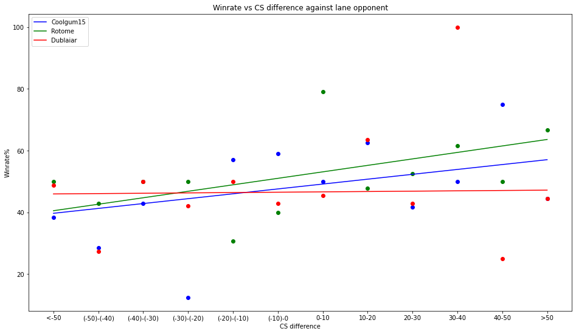

```python
players = ['Coolgum15', 'Rotome', 'Dublaiar']
fig, ax = plt.subplots()
ax.set_ylabel('Winrate%')
ax.set_xlabel('CS difference')
ax.set_title('Winrate vs CS difference against lane opponent')
fig.set_size_inches(16, 9)

#plot cole and regression
ax.scatter(buckets, cole_cs, color = 'blue')
cole_x, cole_y = xy(cole_cs, cole_size)
cole_m, cole_b = np.polyfit(cole_x, cole_y, 1)
ax.plot(['<-50', '>50'],[cole_b, cole_m*11 + cole_b], color = 'blue')

#plot jerry and regression
ax.scatter(buckets, jerry_cs, color = 'green')
jerry_x, jerry_y = xy(jerry_cs, jerry_size)
jerry_m, jerry_b = np.polyfit(jerry_x, jerry_y, 1)
ax.plot(['<-50', '>50'],[jerry_b, jerry_m*11 + jerry_b], color = 'green')

#plot aidan and regression
ax.scatter(buckets, aidan_cs, color = 'red')
aidan_x, aidan_y = xy(aidan_cs, aidan_size)
aidan_m, aidan_b = np.polyfit(aidan_x, aidan_y, 1)
ax.plot(['<-50', '>50'],[aidan_b, aidan_m*11 + aidan_b], color = 'red')

ax.legend(players, loc = 'upper left')
```

The fit on any of these lines is not great, but there is still some information we can unpack here.

Dublaiar's CS score has almost no impact on his performance, meaning that he is not making use of his gold from CS and not pushing his lead further, but does play safe when behind on CS.

Meanwhile, Coolgum15 has high CS, but also the worst performance with low cs. This tells me that I do push my lead to victory, but I can't play safe when I'm behind on CS and end up losing.

Rotome has a very similar regression to mine; However, Rotome has a higher win rate with high CS, meaning that he is pushing his lead more effectively than me. This also tells the rest of my team that if we want to win, our best bet is to get Rotome all the CS he can get.

Commenting on the accuracy of these points and this regression, while most of these CS bucket ranges have sufficient amounts of data, not all of them do. I did have to code around one case where there was 0 data in that bucket, despite there being ~160 games per player. Additionally, outliers like Dublaiar's low win rate at a 40-50 CS lead are dubious and would be ironed out in any sample size larger than this one. Unfortunately for this dataset, my friends and I have lives outside of League of Legends.

# Conclusions

There are several useful conclusions from the gathered data that can push the players to do better as a whole. I will be communicating these with my team in order for us to do better in future games.

David: If our group ever decides to play with David, he doesn't have to worry about switching to his smurf account and can instead focus on playing on his main account, as the matchmaking does not favor his smurf to the group overall.

Jerry (Rotome): Jerry needs to work on playing from behind. His win rates are lower than they could be, and he would benefit from playing safer when he is behind in CS. However, his middle lane game is on point, and he has a solid win rate in the mid-lane and should continue to lane there. Furthermore, since Jerry has the highest winrate while ahead, the team's priority should be to get Jerry CS, as it makes our team more likely to win.

Cole (Coolgum15): As much as I play jungle in order to fill a role for the team, I should either get serious about getting better at jungle or switch to a different role that I am more successful in, like top or support. Additionally, I need to work on my middle lane play, because I'm going to keep playing it because I love it so much. I should probably listen to Jerry about mid-lane and pay attention to his gameplay considering how good his mid win rate is. Furthermore, I play HORRIBLY when behind on CS and need to improve my CS-ing skills in a bad situation, as well as getting better at playing from behind.

Aidan (Dublaiar): Aidan has plenty of areas to improves in, whether that is bot lane overall, or pushing his lead while ahead on CS, or even branching out to other roles. Aidan should most likely shift to support if he cares greatly about win rates.